# S&H Social Media Performance Index

# Análisis del estado **Aguascaliente**

1. Salud
2. Seguridad
3. Economía
4. Servicios

### Ranking

| concepto | fecha_inicio | fecha_fin | posicion_inicio | posicion_fin | incremento_lugares |
| --- | --- | --- | --- | --- | --- |
| rank | 2016-04-22 | 2016-05-22 | 22 | 11 | 11 |
| rank_salud | 2016-04-22 | 2016-05-22 | 28 | 22 | 6 |
| rank_economia | 2016-04-22 | 2016-05-22 | 23 | 9 | 14 |
| rank_seguridad | 2016-04-22 | 2016-05-22 | 19 | 25 | -6 |
| rank_servicios | 2016-04-22 | 2016-05-22 | 16 | 5 | 11 |

**NOTA:** La categoría “general” es el promedio de las categorías restantes, i.e. salud,economia,seguridad y servicios.

### Desempeño del indicador

Para conocer más acerca del indicador visita: http://www.gcn-p.com/metodologia/

A continuación se muestra el desempeño del indicador correspondendientes al estado **Aguascaliente**

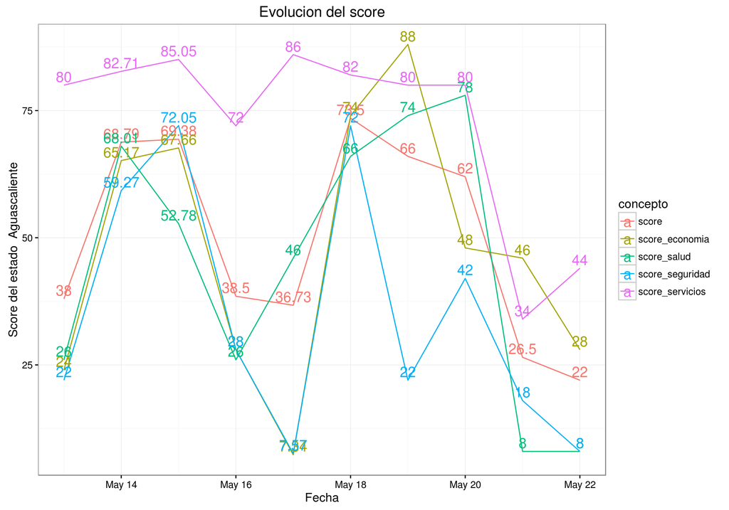

### Evolución de rankeo por categoría

A continuación se muestra la evolución en el ranking por categoría correspondendientes al estado **Aguascaliente**

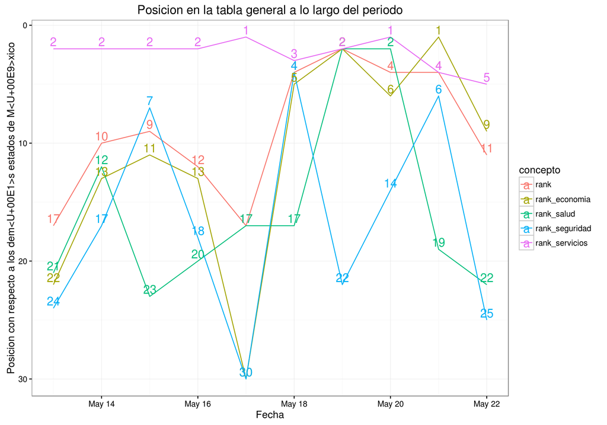

### Temas mas importantes

Los temas más importantes del estado se miden en cuanto al número de apariciones, es decir la frecuencias de estas. A continuación se muestran las palabras con más importantes bajo este contexto durante el periodo **(2016-05-16 - 2016-05-23)** en el estado **Aguascaliente**.

[figure not shown]

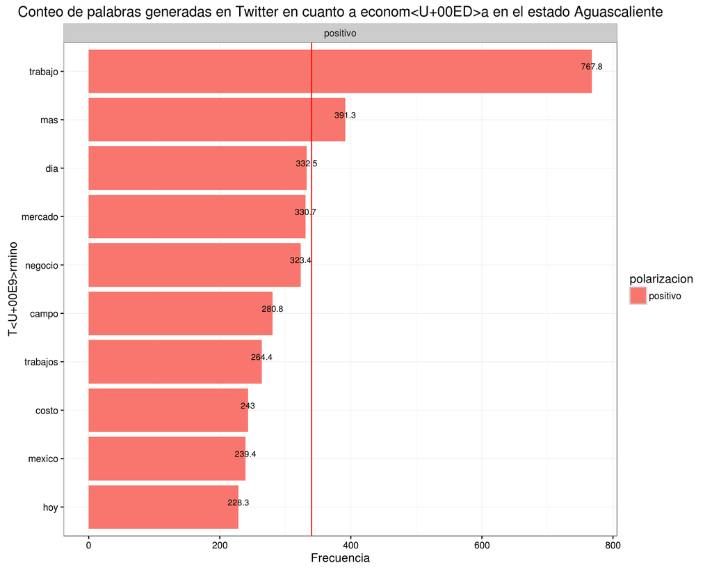

[figure not shown]

[figure not shown]

### Tabla de correlación correspondiente al estado Aguascaliente

Para poder medir la relación que existe entre los indicadores de percepción y medidas oficiales; se utilizó el coeficiente de correlación de Pearson, en el cual se midió la relación de los índices provenientes del INEGI a nivel nacional que son calculados de manera mensual de los principales servicios como son la Generación de Luz y Agua, Desempleo, Manufacturas, Minería y el tipo de cambio. Mientras más cercano sea a 1, quiere decir que ese par de variables están relacionadas positivamente, es decir, cuando una variable tiene un crecimiento a lo largo del tiempo, la otra variable también muestra un crecimiento.

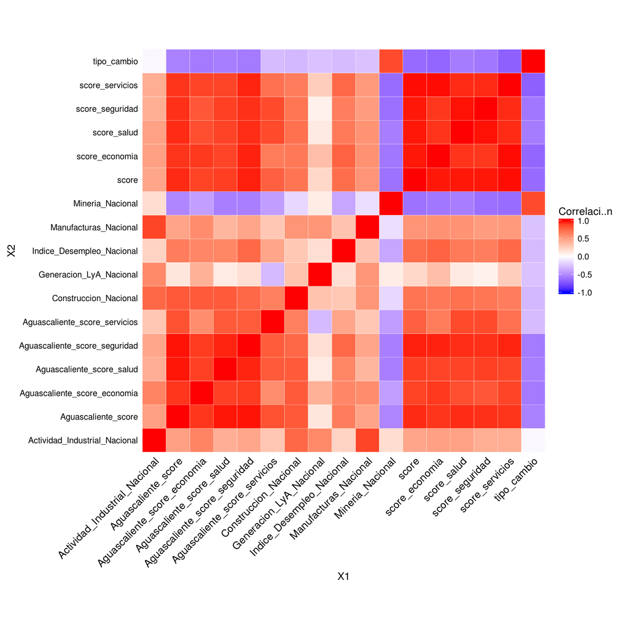

### Políticas Públicas

Siguiendo la misma metodología del indicador del desempeño, aquí solo se muestra la percepción que se tiene considerando aquellas noticias o comentarios de las redes sociales donde explícitamente se mencionan o hacen referencia a los temas de Presidente, Gobiernos Estatales y los Gobernadores dentro de cada estado y al igual que el indicador del desempeño, mientras más cercano este al 100, la percepción dentro del estado es mejor positivamente referente a la categoría en cuestión.

El siguiente análisis muestra un resumen detallado con respecto al desempeño estatal en el periodo **2016-05-15** a **2016-05-22** y en las siguientes categorías:

1. Desempeño Social del Presidente de México
2. Desempeño Social de los Gobernadores en México
3. Desempeño Social de los Gobiernos Estatales

### Índice de Desempeño Social del Presidente de México

La siguiente tabla muestra la informacion del **2016-05-15** al **2016-05-22**.

| estado | score_actual | rank_actual | score_anterior | rank_anterior | cambio_ranking | cambio_score |
| --- | --- | --- | --- | --- | --- | --- |
| Aguascaliente | 88 | 1 | 44.49 | 4 | -75 % | 97.8 % |

[interactive chart not shown]

### Índice de Desempeño Social de los Gobernadores en México

La siguiente tabla muestra la informacion del **2016-05-15** al **2016-05-22**.

| estado | score_actual | rank_actual | score_anterior | rank_anterior | cambio_ranking | cambio_score |
| --- | --- | --- | --- | --- | --- | --- |
| Aguascaliente | 58 | 8 | 35.79 | 16 | -50 % | 62.06 % |

[interactive chart not shown]

### Índice de Desempeño Social de los Gobiernos Estatales en México

La siguiente tabla muestra la informacion del **2016-05-15** al **2016-05-22**.

| estado | score_actual | rank_actual | score_anterior | rank_anterior | cambio_ranking | cambio_score |
| --- | --- | --- | --- | --- | --- | --- |
| Aguascaliente | 8 | 21 | 25.98 | 26 | -19.23 % | -69.21 % |

[interactive chart not shown]